# Advanced Empirical Finance: Topics and Data Science

Return prediction with trees and forests

Stefan Voigt

University of Copenhagen and Danish Finance Institute (DFI)

Spring 2027

## Today

- Two uses of machine learning in asset pricing
- Gu, Kelly & Xiu (2020): machine learning forecasts of stock returns
- Regression trees and random forests
- From forecasts to a portfolio

## Two uses of machine learning

- **Lectures 10 to 12:** estimate the SDF, the best portfolio of the zoo, directly. Its weights are constant
- **Today:** forecast each return, $E_t[r_{i,t+1}] = g(z_{i,t})$, with characteristics and the state of the economy in $z_{i,t}$. The function $g$ may be nonlinear and contain interactions
- A forecast is not yet a portfolio: we need a second step from forecasts to weights

Does a flexible forecast of returns beat a well-shrunk SDF?

# Gu, Kelly & Xiu (2020)

## Empirical asset pricing via machine learning

- **Data:** almost 30,000 US stocks, March 1957 to December 2016, more than 6,200 a month on average
- **Predictors:** 94 characteristics, each interacted with 8 macro predictors (Welch & Goyal), plus 74 industry dummies: $94 \times (8 + 1) + 74 = 920$
- **Samples:** training 1957–1974, validation 1975–1986, test 1987–2016. The models are refitted every year on a growing training sample; the validation sample rolls forward
- **Methods:** OLS, partial least squares, principal component regression, elastic net, generalized linear models, random forests, gradient boosted trees, and neural networks with one to five layers
- Exercise 4 prepares their data with CRSP

## Their forecasts

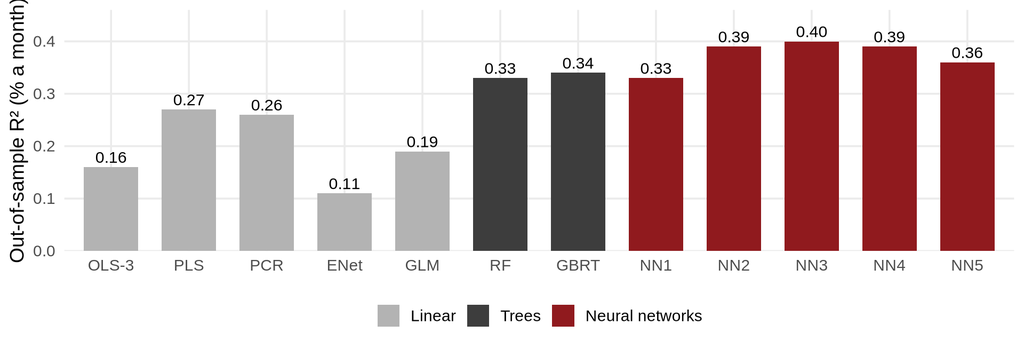

- OLS with all 920 predictors: $R^2_{oos}$ = -3.46%. OLS-3 with size, book-to-market and momentum only: 0.16%
- Trees and networks forecast best, around 0.3 to 0.4% a month. Small, but for stock returns a large number

## What predicts, and what it pays

- **The same few predictors** matter for all methods: price trends (short-term reversal, momentum, industry momentum), liquidity (market value, dollar volume, bid-ask spread) and volatility
- **Portfolios:** sort stocks each month into deciles of the forecast and buy the top, sell the bottom decile. Value-weighted, the four-layer network earns an out-of-sample Sharpe ratio of **1.35**, OLS-3 0.61; equal-weighted 2.45 and 0.83
- **Costs:** these portfolios turn over more than 100% of their value a month (their Table 8). Lecture 15 comes back to this

# Trees and forests

## Whiteboard: regression trees

Split the sample in two, by one predictor and one threshold, so that the forecast errors fall most. Then split each half again

$$\min_{j,\,s} \ \sum_{i:\, z_{ij} < s} (r_i - \bar r_{\text{left}})^2 + \sum_{i:\, z_{ij} \ge s} (r_i - \bar r_{\text{right}})^2$$

- Each leaf forecasts the average return of its observations. Nonlinearities and interactions come for free: a split on momentum, then on last month’s return
- **Depth** sets the complexity: deep trees fit the noise of the sample, and a small change in the data changes the whole tree

## The zoo as a panel

- R
- Python

```r
# Macro predictors of month t - 1, known when month t starts, scaled with
# the estimation sample
macro <- read_parquet("data/macro_predictors.parquet") |>
  transmute(date = date %m+% months(1), across(all_of(macro_names))) |>
  mutate(across(all_of(macro_names), \(x) (x - mean(x[date < test_start])) / sd(x[date < test_start])))

panel <- anomalies |>
  pivot_longer(-date, names_to = "anomaly", values_to = "ret") |>
  mutate(ret = ret / 100) |>
  arrange(anomaly, date) |>
  mutate(
    ret_lag_1 = lag(ret),
    momentum_12 = slider::slide_dbl(lag(ret), mean, .before = 11, .complete = TRUE),
    .by = anomaly
  ) |>
  left_join(macro, join_by(date)) |>
  drop_na()
```

```python
# Macro predictors of month t - 1, known when month t starts, scaled with
# the estimation sample
macro_names = ["dp", "tbl", "tms", "dfy", "svar"]
macro = (pl.read_parquet("data/macro_predictors.parquet")
    .select(pl.col("date").dt.offset_by("1mo"), *macro_names))
in_estimation = pl.col("date") < date(2000, 1, 1)
macro = macro.with_columns(
    [((pl.col(c) - pl.col(c).filter(in_estimation).mean()) / pl.col(c).filter(in_estimation).std()).alias(c)
     for c in macro_names])

panel = (anomalies.select("date", *complete)
    .unpivot(index="date", variable_name="anomaly", value_name="ret")
    .with_columns(pl.col("ret") / 100)
    .sort("anomaly", "date")
    .with_columns(ret_lag_1=pl.col("ret").shift(1).over("anomaly"),
                  momentum_12=pl.col("ret").shift(1).rolling_mean(12).over("anomaly"))
    .join(macro, on="date", how="left")
    .drop_nulls())
```

One row per anomaly and month: the return $r_{i,t+1}$, last month’s return, the average return over the last 12 months (factor momentum) and five macro predictors. `anomalies` and `complete` as in lecture 10

## A tree on the zoo

- R
- Python

```r
train <- panel |> filter(date < test_start)
tree <- rpart(
  ret ~ momentum_12 + ret_lag_1, data = train,
  control = rpart.control(maxdepth = 2, minbucket = 500, cp = 0)
)
```

```python
train = panel.filter(pl.col("date") < date(2000, 1, 1))
tree = DecisionTreeRegressor(max_depth=2, min_samples_leaf=500).fit(
    train.select("momentum_12", "ret_lag_1"), train["ret"])
```

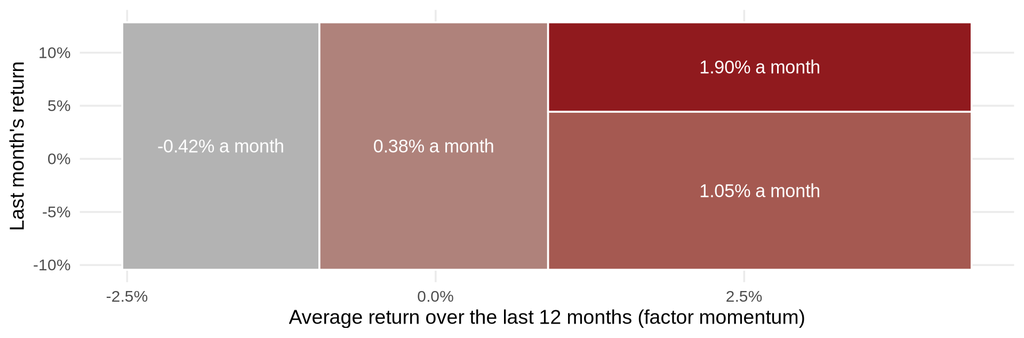

- The first split is on factor momentum: anomalies that did well over the last year keep doing well (Ehsani & Linnainmaa, 2022). Among them, last month’s winners earn most

## Random forests

- **Bagging:** grow many deep trees, each on a bootstrap sample of the data, and average their forecasts. Averaging removes much of the variance of single trees
- **Random predictors:** at each split, a tree may use only a random subset of `mtry` predictors. The trees differ more, so their average gains more
- **Tuning parameters:** the number of predictors per split (`mtry`) and the smallest node that may still be split (`min_n`). Choose them by cross-validation on consecutive blocks of time, as in lecture 11

## Tuning a forest in R and Python

- R
- Python

```r
# Five consecutive blocks of months, as in lecture 11
train <- train |> mutate(block = ceiling(dense_rank(date) / (n_distinct(date) / n_folds)))
forest_model <- rand_forest(mtry = tune(), min_n = tune(), trees = n_trees) |>
  set_engine("ranger", seed = 2027) |>
  set_mode("regression")
forest_workflow <- workflow() |>
  add_formula(ret ~ ret_lag_1 + momentum_12 + dp + tbl + tms + dfy + svar) |>
  add_model(forest_model)
forest_tuning <- tune_grid(
  forest_workflow, resamples = group_vfold_cv(train, group = block, v = n_folds), grid = forest_grid
)
forest_fit <- forest_workflow |>
  finalize_workflow(select_best(forest_tuning, metric = "rmse")) |>
  fit(train)
```

```python
# Five consecutive blocks of months, as in lecture 11
features = ["ret_lag_1", "momentum_12", *macro_names]
months = train["date"].rank("dense")
blocks = np.ceil(months / (months.max() / n_folds)).to_numpy()
search = GridSearchCV(
    RandomForestRegressor(n_estimators=100, random_state=2027, n_jobs=-1),
    {"max_features": [1, 3, 7], "min_samples_split": [500, 2000]},
    cv=GroupKFold(n_splits=n_folds), scoring="neg_root_mean_squared_error",
)
search.fit(train.select(features), train["ret"], groups=blocks)
```

100 trees per forest for the tuning; `ranger` and scikit-learn draw different random trees, so their forecasts differ a little

# From forecasts to a portfolio

## Forecasts as expected returns

$$\omega_t = (\hat\Sigma + \lambda I)^{-1}\,\hat\mu_t \qquad \hat\mu_t: \text{the forecasts for all anomalies in month } t$$

| Forecast | Out-of-sample R² | Sharpe ratio 1974–1999 | Sharpe ratio 2000–2023 |
| --- | --- | --- | --- |
| OLS | 0.65% | 8.68 | 1.13 |
| Tree of depth 2 | 0.94% | 8.45 | 1.45 |
| Random forest | 1.77% | 6.42 | 1.75 |

- The covariance matrix and the penalty are those of the ridge SDF of lecture 11 (Sharpe ratio 2.89 in the test sample); only the expected returns change every month
- The tuned forest uses 1 of the 7 predictors per split and nodes of at least 2000 anomaly-months. No forecast portfolio comes near the static ridge SDF

## Scoreboard

| Portfolio | Inputs | Sharpe ratio, estimation | Sharpe ratio 2000–2023 |
| --- | --- | --- | --- |
| Ridge (prior on Sharpe ratios) | 158 anomalies | 12.92 | 2.89 |
| Forecasts: OLS | 7 predictors | 8.68 | 1.13 |
| Forecasts: Tree of depth 2 | 7 predictors | 8.45 | 1.45 |
| Forecasts: Random forest | 7 predictors | 6.42 | 1.75 |

- Forecasts need 12 months of history, so their estimation sample starts in 1974; the rows of lectures 10 to 12 stay on the scoreboard
- **Lecture 14:** a neural network for the forecasts, and a network that learns the SDF directly